# STAT3040 Group Work

N. Della; T. McCallum; B. Moran

```
## [1] 4e-04
```

```
## [1] 0.03358333
```

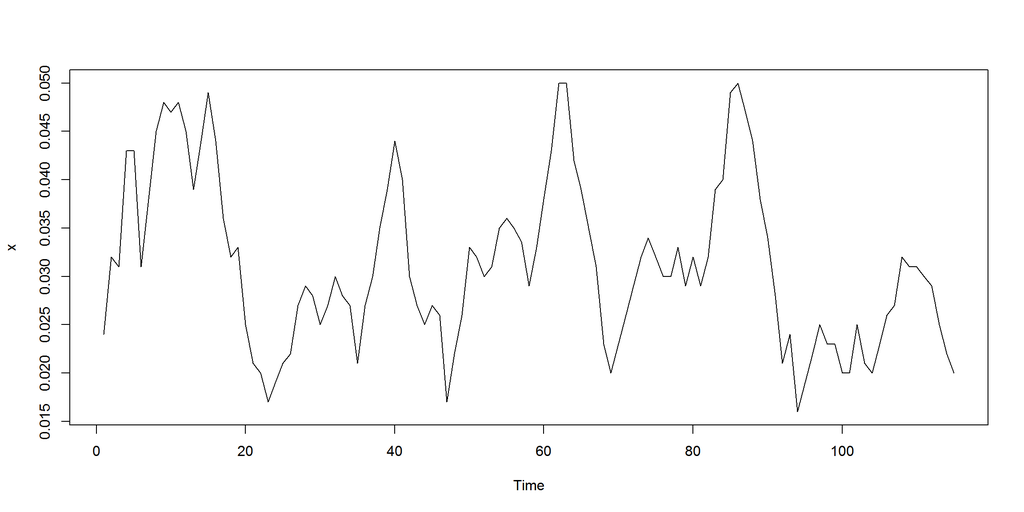

Not stationary (why?), so difference by 1 lag.

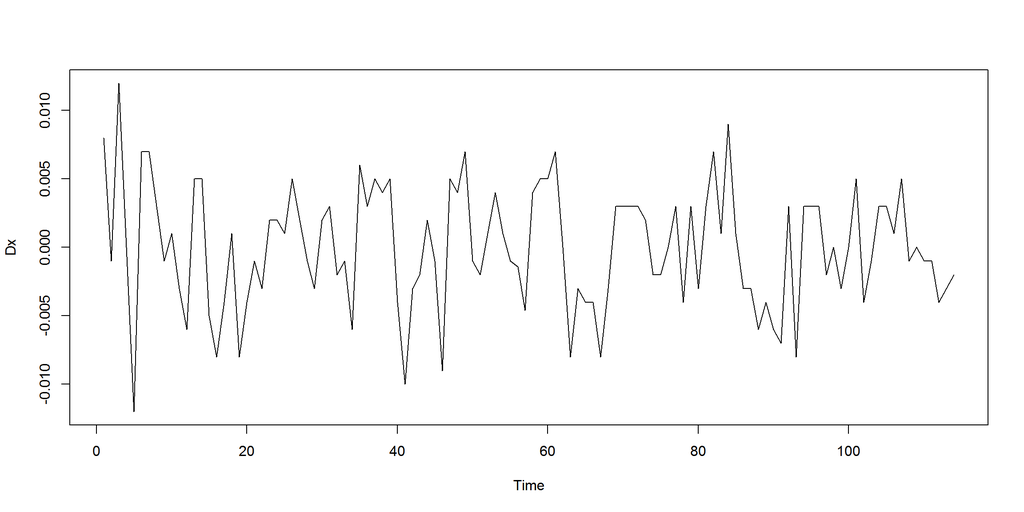

And if we difference by 2 lags:

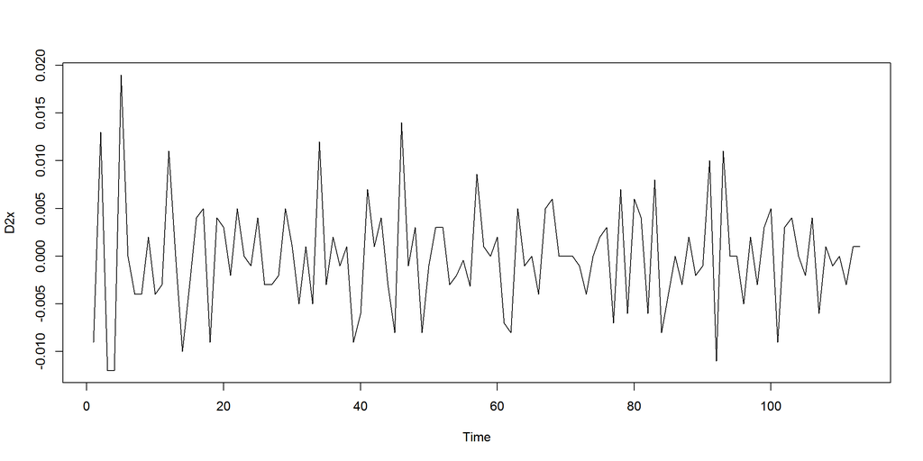

Plot ACF and PACF

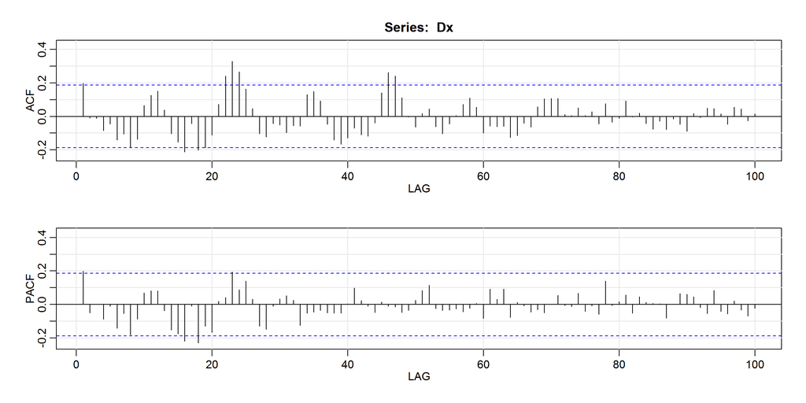

```
## [1] 0.92
## [1] "No"
```

```
## [1] 0.97
## [1] "Yes"
```

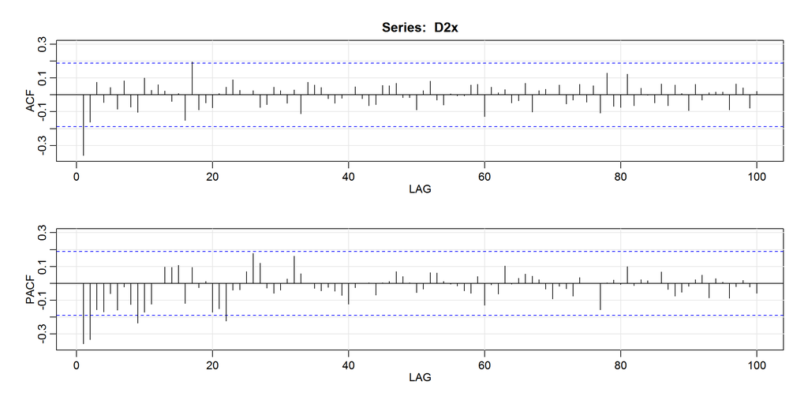

```
## [1] 0.98
## [1] "Yes"
```

```
## [1] 0.96
## [1] "Yes"
```

Let’s try different ARMA(p,q) models for Dx:

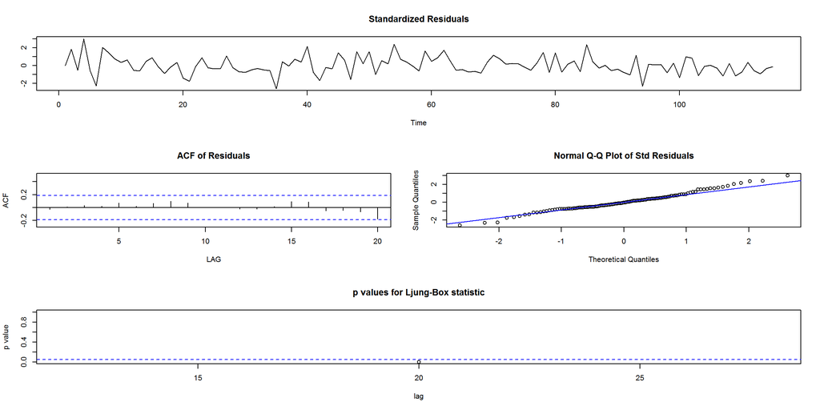

```
## $fit
##
## Call:
## stats::arima(x = xdata, order = c(p, d, q), seasonal = list(order = c(P, D,
##     Q), period = S), xreg = constant, optim.control = list(trace = trc, REPORT = 1,
##     reltol = tol))
##
## Coefficients:
##          ar1      ar2     ar3      ar4     ar5      ar6     ar7      ar8
##       0.5672  -0.2253  0.0600  -0.1315  0.0242  -0.1408  0.0043  -0.2209
## s.e.  0.1427   0.1031  0.1073   0.1072  0.1056   0.1104  0.1132   0.1118
##           ar9    ar10     ar11     ar12     ar13     ar14     ar15
##       -0.0982  0.0462  -0.0116  -0.0326  -0.0215  -0.1607  -0.1236
## s.e.   0.1223  0.1167   0.1136   0.1131   0.1107   0.1141   0.1143
##          ar16    ar17     ar18      ma1  constant
##       -0.1835  0.1986  -0.3374  -0.5577    -1e-04
## s.e.   0.1168  0.1178   0.0991   0.1284     1e-04
##
## sigma^2 estimated as 1.239e-05:  log likelihood = 479.2,  aic = -916.4
##
## $degrees_of_freedom
## [1] 95
##
## $ttable
##          Estimate     SE t.value p.value
## ar1        0.5672 0.1427  3.9736  0.0001
## ar2       -0.2253 0.1031 -2.1844  0.0314
## ar3        0.0600 0.1073  0.5594  0.5772
## ar4       -0.1315 0.1072 -1.2271  0.2228
## ar5        0.0242 0.1056  0.2292  0.8192
## ar6       -0.1408 0.1104 -1.2755  0.2052
## ar7        0.0043 0.1132  0.0379  0.9699
## ar8       -0.2209 0.1118 -1.9767  0.0510
## ar9       -0.0982 0.1223 -0.8029  0.4240
## ar10       0.0462 0.1167  0.3961  0.6929
## ar11      -0.0116 0.1136 -0.1022  0.9188
## ar12      -0.0326 0.1131 -0.2882  0.7738
## ar13      -0.0215 0.1107 -0.1943  0.8463
## ar14      -0.1607 0.1141 -1.4091  0.1621
## ar15      -0.1236 0.1143 -1.0816  0.2822
## ar16      -0.1835 0.1168 -1.5702  0.1197
## ar17       0.1986 0.1178  1.6861  0.0951
## ar18      -0.3374 0.0991 -3.4049  0.0010
## ma1       -0.5577 0.1284 -4.3438  0.0000
## constant  -0.0001 0.0001 -0.9166  0.3617
##
## $AIC
## [1] -9.950544
##
## $AICc
## [1] -9.846757
##
## $BIC
## [1] -10.47316
```

Looking at the ACF for Dx, we note that there does appear to be seasonality. Each flu season has 23 weeks, and we observe spikes in the ACF every 23 weeks. So let’s try to account for seasonality.

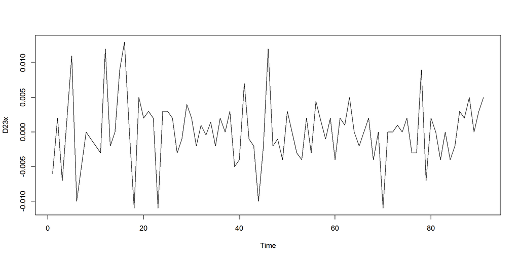

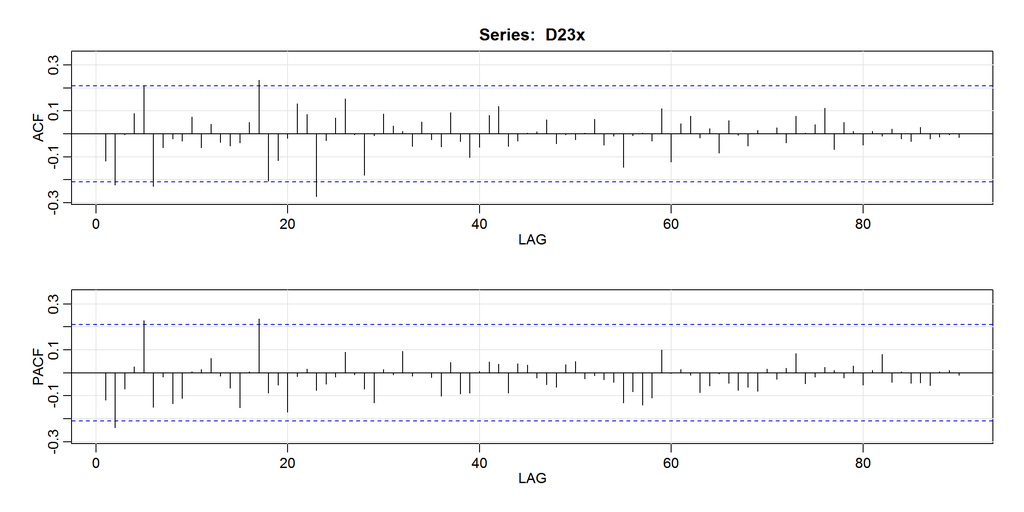

```
## [1] 0.9333333
## [1] "No"
```

```
## [1] 0.9666667
## [1] "Yes"
```

Let’s try to fit a SARIMA model for D23x: Using good/bad to say whether final coefficients are significant. i.e. if the model is arima(2,1,3), I only need the AR(2) and MA(3) coefficients to be significant. Also, for better reasoning on choosing p,d,q,P,D,Q,S, look further down the page for where we fit a model to the data from vaccinated respondents.

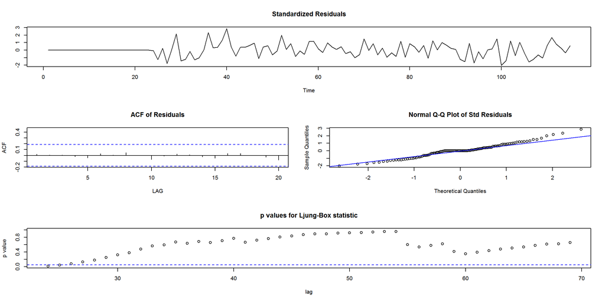

```
## $fit
##
## Call:
## stats::arima(x = xdata, order = c(p, d, q), seasonal = list(order = c(P, D,
##     Q), period = S), include.mean = !no.constant, optim.control = list(trace = trc,
##     REPORT = 1, reltol = tol))
##
## Coefficients:
##           ar1     ar2      ar3     ar4     ar5      ar6      ar7      ar8
##       -0.3047  0.0325  -0.0764  0.4645  0.7030  -0.0723  -0.1023  -0.1645
## s.e.   0.2343  0.1576   0.1521  0.1286  0.1937   0.1464   0.1426   0.1432
##           ar9    ar10    ar11    ar12    ar13     ar14     ar15     ar16
##       -0.2061  0.1374  0.2507  0.0425  0.0177  -0.1284  -0.1869  -0.0498
## s.e.   0.1511  0.1497  0.1613  0.1596  0.1460   0.1222   0.1362   0.1376
##         ar17     ma1      ma2     ma3      ma4      ma5     sma1
##       0.2730  0.0873  -0.1476  0.2797  -0.4827  -0.7367  -0.2686
## s.e.  0.1327  0.2347   0.1997  0.1524   0.1333   0.2037   0.1571
##
## sigma^2 estimated as 1.131e-05:  log likelihood = 381.43,  aic = -714.87
##
## $degrees_of_freedom
## [1] 92
##
## $ttable
##      Estimate     SE t.value p.value
## ar1   -0.3047 0.2343 -1.3005  0.1967
## ar2    0.0325 0.1576  0.2065  0.8368
## ar3   -0.0764 0.1521 -0.5021  0.6168
## ar4    0.4645 0.1286  3.6113  0.0005
## ar5    0.7030 0.1937  3.6290  0.0005
## ar6   -0.0723 0.1464 -0.4936  0.6228
## ar7   -0.1023 0.1426 -0.7177  0.4748
## ar8   -0.1645 0.1432 -1.1491  0.2535
## ar9   -0.2061 0.1511 -1.3640  0.1759
## ar10   0.1374 0.1497  0.9179  0.3611
## ar11   0.2507 0.1613  1.5545  0.1235
## ar12   0.0425 0.1596  0.2662  0.7907
## ar13   0.0177 0.1460  0.1212  0.9038
## ar14  -0.1284 0.1222 -1.0506  0.2962
## ar15  -0.1869 0.1362 -1.3727  0.1732
## ar16  -0.0498 0.1376 -0.3623  0.7180
## ar17   0.2730 0.1327  2.0572  0.0425
## ma1    0.0873 0.2347  0.3720  0.7108
## ma2   -0.1476 0.1997 -0.7390  0.4618
## ma3    0.2797 0.1524  1.8350  0.0697
## ma4   -0.4827 0.1333 -3.6211  0.0005
## ma5   -0.7367 0.2037 -3.6168  0.0005
## sma1  -0.2686 0.1571 -1.7096  0.0907
##
## $AIC
## [1] -9.989615
##
## $AICc
## [1] -9.856281
##
## $BIC
## [1] -10.44063
```

```
## $pred
## Time Series:
## Start = 116
## End = 125
## Frequency = 1
##  [1] 0.02040367 0.01367003 0.01651088 0.02295246 0.02232240 0.02037911
##  [7] 0.01966240 0.01978926 0.02059020 0.02122240
##
## $se
## Time Series:
## Start = 116
## End = 125
## Frequency = 1
##  [1] 0.003419454 0.004374365 0.005044263 0.005982257 0.006726142
##  [6] 0.007285688 0.007553138 0.007844145 0.008100740 0.008197360
```

Let’s try to fit a model omitting the final 2 values, then predict the next 2 values and compare to the actual ones

```
## $pred
## Time Series:
## Start = 114
## End = 115
## Frequency = 1
## [1] 0.02340980 0.01855307
##
## $se
## Time Series:
## Start = 114
## End = 115
## Frequency = 1
## [1] 0.003454629 0.004437987
```

```
## [1] 0.022 0.020
```

Do the actual 114th and 115th values of the time series lie within the 95% bounds of our predicted 114th and 115th values? (Make this look nicer)

```
## [1] 0.01663872 0.02200000 0.03018087
```

```
## [1] 0.009854618 0.020000000 0.027251528
```

Yes (above shows the lower CI, actual value, upper CI) Plotting actual vs predicted:

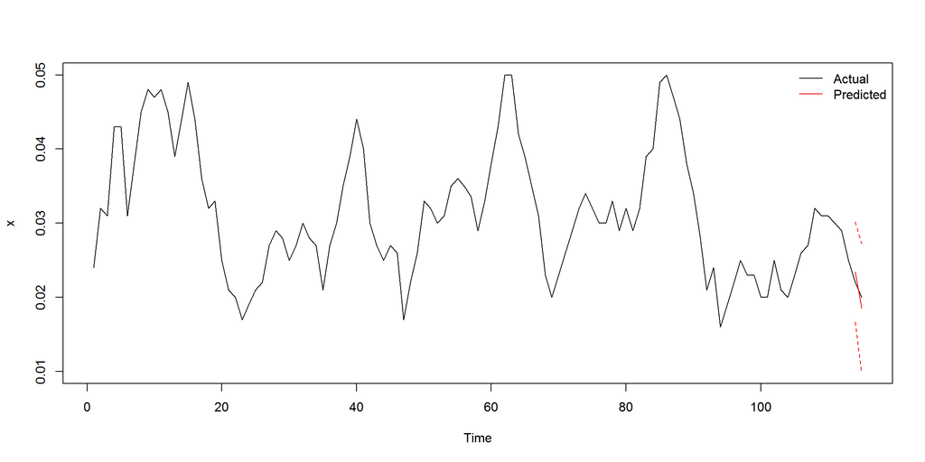

As you can see from this plot, the next two values the time series (red line) predicts are very close to the actual values (black line). Certainly, the actual values lie well within the 95% confidence bounds (dotted red lines).

Note: We can also predict value for Oct 16, 2016, which we have the data for but omitted so that we had 23 weeks per season.

### Pre-whitening: (NB: This did not work. Do we still include? Maybe in report, not poster.)

Let’s take a look at the Google Trends data:

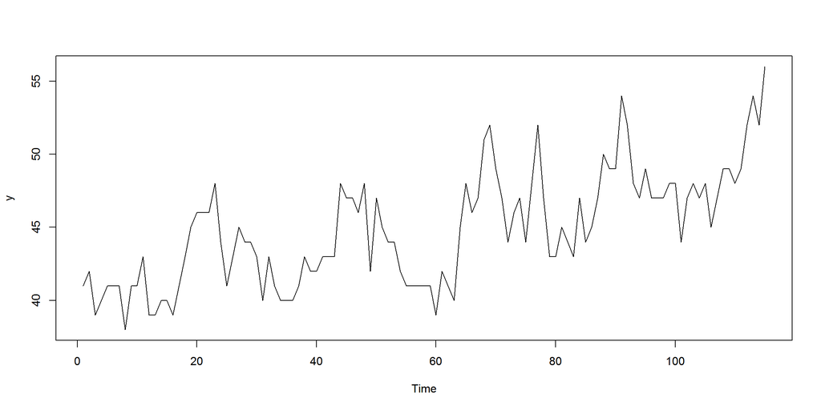

Not stationary. Try differencing.

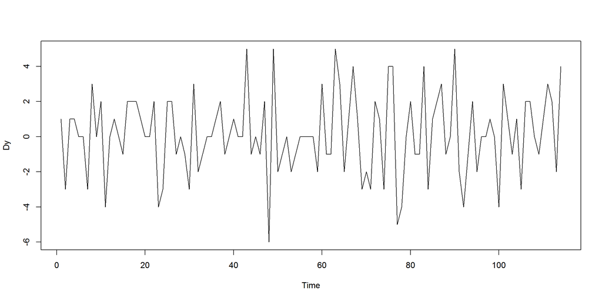

Fit an ARMA model to the differenced data.

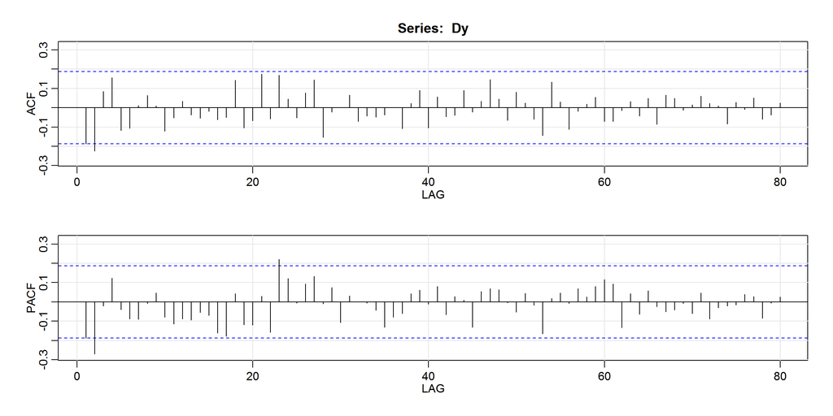

```
## [1] 0.9875
## [1] "Yes"
```

```
## [1] 0.9875
## [1] "Yes"
```

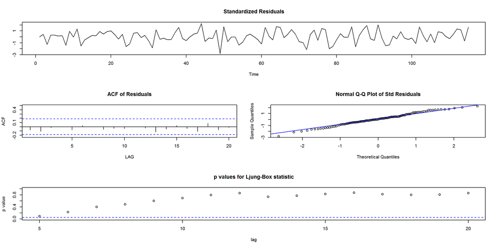

```
## $fit
##
## Call:
## stats::arima(x = xdata, order = c(p, d, q), seasonal = list(order = c(P, D,
##     Q), period = S), include.mean = !no.constant, optim.control = list(trace = trc,
##     REPORT = 1, reltol = tol))
##
## Coefficients:
##          ar1      ar2      ma1     ma2
##       0.2938  -0.9191  -0.4733  1.0000
## s.e.  0.0382   0.0381   0.0270  0.0527
##
## sigma^2 estimated as 4.205:  log likelihood = -246.21,  aic = 502.41
##
## $degrees_of_freedom
## [1] 111
##
## $ttable
##     Estimate     SE  t.value p.value
## ar1   0.2938 0.0382   7.6856       0
## ar2  -0.9191 0.0381 -24.1349       0
## ma1  -0.4733 0.0270 -17.5042       0
## ma2   1.0000 0.0527  18.9879       0
##
## $AIC
## [1] 2.505817
##
## $AICc
## [1] 2.527995
##
## $BIC
## [1] 1.601293
```

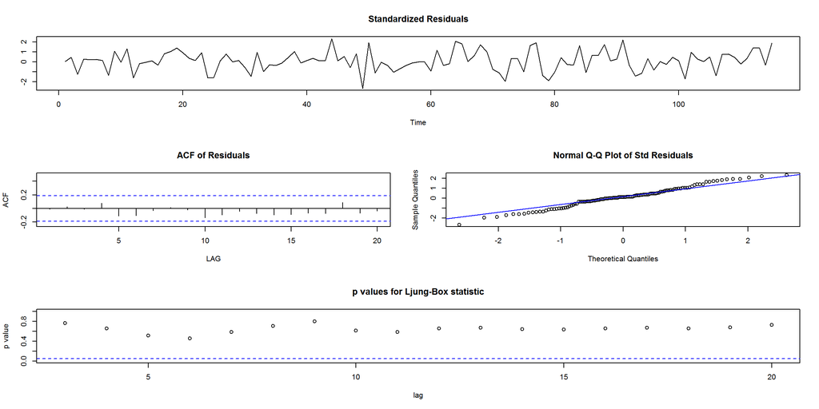

```
## $fit
##
## Call:
## stats::arima(x = xdata, order = c(p, d, q), seasonal = list(order = c(P, D,
##     Q), period = S), include.mean = !no.constant, optim.control = list(trace = trc,
##     REPORT = 1, reltol = tol))
##
## Coefficients:
##           ar1      ar2
##       -0.2344  -0.2692
## s.e.   0.0911   0.0914
##
## sigma^2 estimated as 4.691:  log likelihood = -249.96,  aic = 505.92
##
## $degrees_of_freedom
## [1] 113
##
## $ttable
##     Estimate     SE t.value p.value
## ar1  -0.2344 0.0911 -2.5737  0.0114
## ar2  -0.2692 0.0914 -2.9446  0.0039
##
## $AIC
## [1] 2.580526
##
## $AICc
## [1] 2.599798
##
## $BIC
## [1] 1.628264
```

Similar AICc, but we want a model with no MA terms. So use the 2nd.

```
##        ar1        ar2
## -0.2343787 -0.2691571
```

Filter the time series x using the model for y

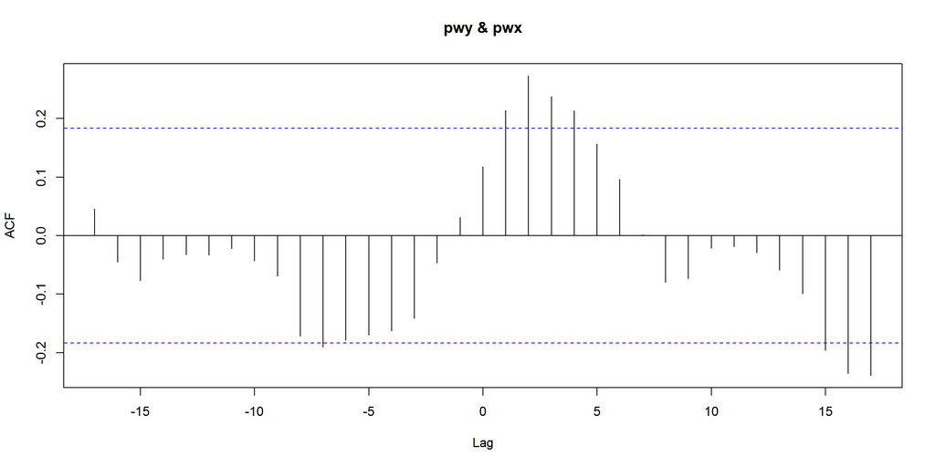

We should also try fitting a model to the vaccinated survey respondents (i.e. % ofvaccinated survey respondents who report flu-related symptoms during a given week).

```
## [1] 3e-04
```

```
## [1] 0.02883333
```

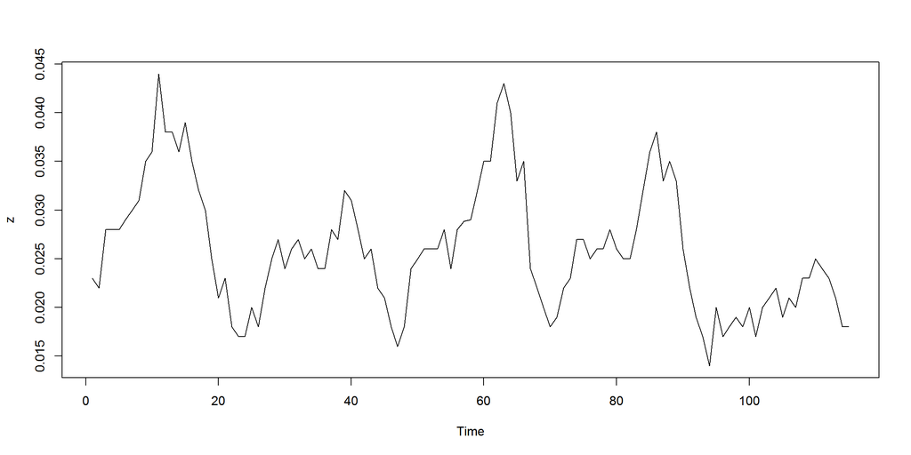

Not stationary (why?), so difference by one lag

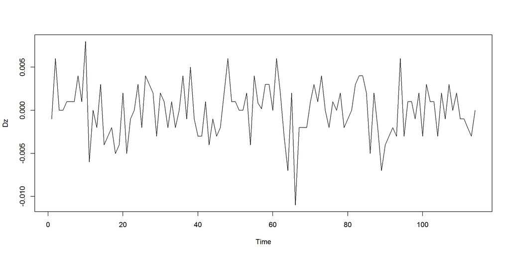

There is an outlier. Difference by 2 lags?

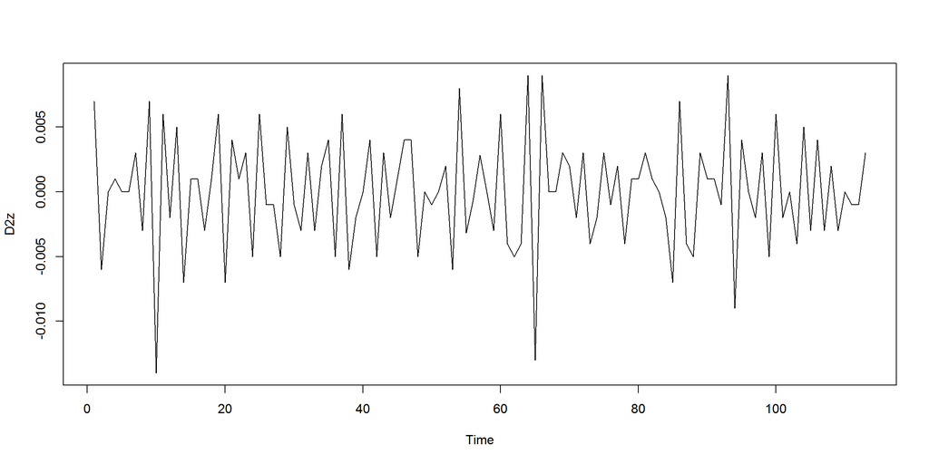

Same outlier. We will use Dz for now, but this is bad.

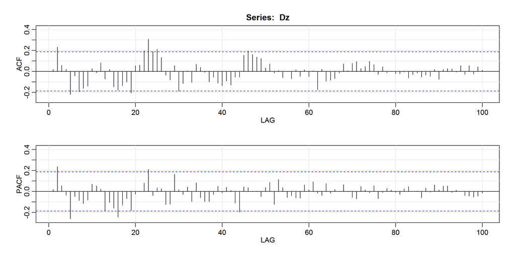

```
## [1] 0.93
## [1] "No"
```

```
## [1] 0.95
## [1] "Yes"
```

There is still a seasonal effect every 23 weeks. So let’s account for seasonality.

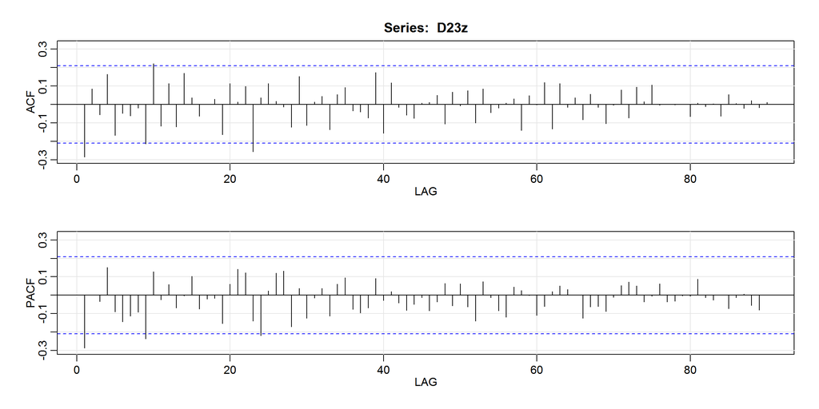

```
## [1] 0.9555556
## [1] "Yes"
```

```
## [1] 0.9666667
## [1] "Yes"
```

Looking at the seasons (every 23 lags), the ACF has a spike at 23 (i.e. Q=1). We can say either the ACF tails off, in which case we can choose a value for P (say P=1, as there is a spike in the PACF at 23); or we can say the ACF cuts off, in which case P=0 by definition. Looking within each 23 week season, we can say that: the ACF cuts off at 1 (q=1 & p=0); we can say the ACF trails off with a spike at 1 and the PACF trails off with a spike at 1 (q=1 & p=1); we can say that the PACF cuts off at 1 (p=1 & q=0). Also consider possible spikes in the ACF and PACF at lag 9.

Cases where P=0 and Q=1

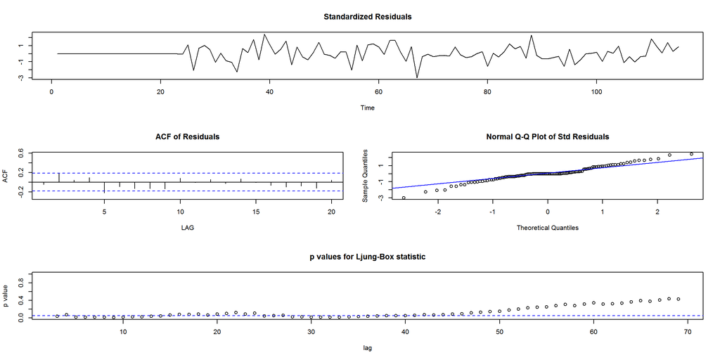

```
## $fit
##
## Call:
## stats::arima(x = xdata, order = c(p, d, q), seasonal = list(order = c(P, D,
##     Q), period = S), include.mean = !no.constant, optim.control = list(trace = trc,
##     REPORT = 1, reltol = tol))
##
## Coefficients:
##           ma1     sma1
##       -0.2184  -0.6634
## s.e.   0.0875   0.2352
##
## sigma^2 estimated as 8.367e-06:  log likelihood = 396.34,  aic = -786.67
##
## $degrees_of_freedom
## [1] 113
##
## $ttable
##      Estimate     SE t.value p.value
## ma1   -0.2184 0.0875 -2.4959  0.0140
## sma1  -0.6634 0.2352 -2.8205  0.0057
##
## $AIC
## [1] -10.65648
##
## $AICc
## [1] -10.63721
##
## $BIC
## [1] -11.60875
```

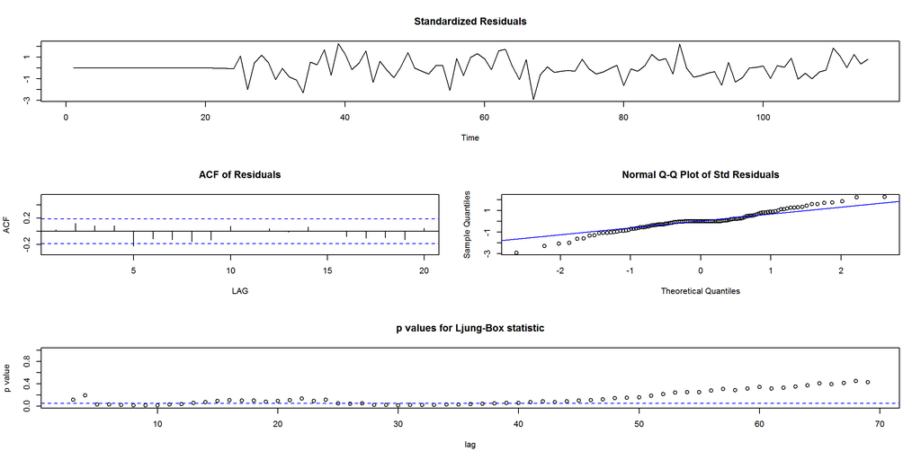

```
## $fit
##
## Call:
## stats::arima(x = xdata, order = c(p, d, q), seasonal = list(order = c(P, D,
##     Q), period = S), include.mean = !no.constant, optim.control = list(trace = trc,
##     REPORT = 1, reltol = tol))
##
## Coefficients:
##           ar1     sma1
##       -0.2828  -0.6942
## s.e.   0.1005   0.2545
##
## sigma^2 estimated as 8.062e-06:  log likelihood = 397.23,  aic = -788.46
##
## $degrees_of_freedom
## [1] 113
##
## $ttable
##      Estimate     SE t.value p.value
## ar1   -0.2828 0.1005 -2.8139  0.0058
## sma1  -0.6942 0.2545 -2.7276  0.0074
##
## $AIC
## [1] -10.69359
##
## $AICc
## [1] -10.67432
##
## $BIC
## [1] -11.64585
```

```
## $pred
## Time Series:
## Start = 116
## End = 125
## Frequency = 1
##  [1] 0.01576768 0.01586229 0.01998301 0.01999209 0.02184931 0.02258010
##  [7] 0.02148729 0.02312899 0.02208322 0.02407620
##
## $se
## Time Series:
## Start = 116
## End = 125
## Frequency = 1
##  [1] 0.002879329 0.003534874 0.004205850 0.004753199 0.005251460
##  [6] 0.005704361 0.006124389 0.006517262 0.006887800 0.007239387
```

```
## $pred
## Time Series:
## Start = 106
## End = 115
## Frequency = 1
##  [1] 0.02295094 0.02483458 0.02897491 0.03016796 0.02617466 0.02470814
##  [7] 0.02395054 0.01700850 0.01382196 0.01122002
##
## $se
## Time Series:
## Start = 106
## End = 115
## Frequency = 1
##  [1] 0.003000689 0.003625017 0.004317585 0.004866375 0.005372887
##  [6] 0.005831541 0.006257880 0.006656601 0.007032866 0.007389958
```

```
##  [1] 0.019 0.021 0.020 0.023 0.023 0.025 0.024 0.023 0.021 0.018 0.018
```

```
##                [,1]  [,2]       [,3]
##  [1,]  1.706959e-02 0.021 0.02883229
##  [2,]  1.772955e-02 0.020 0.03193961
##  [3,]  2.051245e-02 0.023 0.03743738
##  [4,]  2.062986e-02 0.023 0.03970605
##  [5,]  1.564381e-02 0.025 0.03670552
##  [6,]  1.327832e-02 0.024 0.03613796
##  [7,]  1.168510e-02 0.023 0.03621599
##  [8,]  3.961558e-03 0.021 0.03005544
##  [9,]  3.754473e-05 0.018 0.02760638
## [10,] -3.264299e-03 0.018 0.02570434
```

Yes (above shows the lower CI, actual value, upper CI) Plotting actual vs predicted:

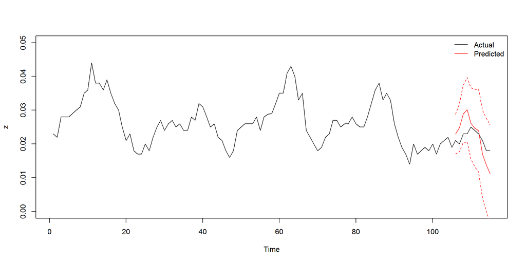